# Customization

Source: [`vignettes/Customization.Rmd`](https://github.com/ModelOriented/corrgrapher/blob/master/vignettes/Customization.Rmd)

## Custom correlation coefficients

### calculate_cors function

As mentioned in introduction, calculating comparable correlation coefficients between variables of different types is a non-trivial problem. The `CorrGrapheR` package provides user with ability to experiment with different measures of correlation, using `calculate_cors` function.

The `num_num_f`, `num_cat_f` and `cat_cat_f` arguments should be functions, used to calculate correlation coefficients between different pairs variables, respectively. Each of them should take 2 arguments (vectors of equal length; for `num_num_f` - both `numeric`, for `cat_cat_f` - both `factor`, for `num_cat_f` - **first** `numeric` and **second** `factor`) and return a single number. It should be interpretable in the following way: the bigger its absolute value, the stronger correlation between variables. If it’s negative - the variables are negatively correlated.

When supplying custom functions, a `max_cor` argument is required. It should be a single number indicating strongest possible correlation (like 1 in Pearson’s `cor.test`). It is used when calculating correlation between the same variables, to trim accidental results above it and to scale final results into $[-1,1]$ range.

The `calculate_cors` returns a correlation `matrix`, similarly to `cor`.

```
library(corrgrapher)
df <- as.data.frame(datasets::Seatbelts)[,1:5]
f1 <- function(x, y) cor.test(x, y, method = 'pearson')$estimate
f2 <- function(x, y) cor.test(x, y, method = 'kendall')$estimate
f3 <- function(x, y) cor.test(x, y, method = 'spearman', exact = FALSE)$estimate
calculate_cors(df, num_num_f = f1, max_cor = 1)
#>               DriversKilled    drivers      front      rear        kms
#> DriversKilled     1.0000000  0.8888264  0.7067596 0.3533510 -0.3211016
#> drivers           0.8888264  1.0000000  0.8084114 0.3436685 -0.4447631
#> front             0.7067596  0.8084114  1.0000000 0.6202248 -0.3573823
#> rear              0.3533510  0.3436685  0.6202248 1.0000000  0.3330069
#> kms              -0.3211016 -0.4447631 -0.3573823 0.3330069  1.0000000
calculate_cors(df, num_num_f = f2, max_cor = 1)
#>               DriversKilled    drivers      front      rear        kms
#> DriversKilled     1.0000000  0.6785708  0.5085310 0.2602347 -0.1870987
#> drivers           0.6785708  1.0000000  0.6262218 0.2426445 -0.2895965
#> front             0.5085310  0.6262218  1.0000000 0.4518703 -0.2270979
#> rear              0.2602347  0.2426445  0.4518703 1.0000000  0.2135214
#> kms              -0.1870987 -0.2895965 -0.2270979 0.2135214  1.0000000
calculate_cors(df, num_num_f = f3, max_cor = 1)
#>               DriversKilled    drivers      front      rear        kms
#> DriversKilled     1.0000000  0.8579854  0.6936970 0.3835558 -0.2686338
#> drivers           0.8579854  1.0000000  0.8225164 0.3641043 -0.4234322
#> front             0.6936970  0.8225164  1.0000000 0.6086036 -0.3511428
#> rear              0.3835558  0.3641043  0.6086036 1.0000000  0.3140946
#> kms              -0.2686338 -0.4234322 -0.3511428 0.3140946  1.0000000
```

As we see, user has to supply only necessary functions for given `x` argument. For a `data.frame` only with `numeric` data only `num_num_f` is required.

Since correlation measures for different data variables are **not** comparable in most cases, it required from the user to **always** supply **all** necessary functions. Naturally, user might supply function identical to the default:

```
data(dragons, package = 'DALEX')
f1 <- function(x, y) -log10(cor.test(x, y, method = 'spearman', exact = FALSE)$p.value)
f2 <- function(x, y) -log10(kruskal.test(x, y)$p.value)
calculate_cors(dragons,
               num_num_f = f1,
               num_cat_f = f2,
               max_cor = 100)
#>                      year_of_birth       height       weight       scars
#> year_of_birth         1.0000000000 0.0040428398 1.084646e-02 0.005151935
#> height                0.0040428398 1.0000000000 1.000000e+00 0.001298727
#> weight                0.0108464600 1.0000000000 1.000000e+00 0.006402918
#> scars                 0.0051519347 0.0012987272 6.402918e-03 1.000000000
#> colour                0.0068233038 0.0004765201 4.282685e-05 0.003525012
#> year_of_discovery     0.0098803614 0.0030892743 2.337062e-03 0.040962737
#> number_of_lost_teeth  0.0007526137 0.0101897329 7.369186e-03 0.004277834
#> life_length           0.0104123400 0.0071877845 1.186213e-02 1.000000000
#>                            colour year_of_discovery number_of_lost_teeth
#> year_of_birth        6.823304e-03      0.0098803614         0.0007526137
#> height               4.765201e-04      0.0030892743         0.0101897329
#> weight               4.282685e-05      0.0023370625         0.0073691861
#> scars                3.525012e-03      0.0409627374         0.0042778339
#> colour               1.000000e+00      0.0060860485         0.0081442241
#> year_of_discovery    6.086049e-03      1.0000000000         0.0001690691
#> number_of_lost_teeth 8.144224e-03      0.0001690691         1.0000000000
#> life_length          3.046990e-03      0.0184173931         1.0000000000
#>                      life_length
#> year_of_birth        0.010412340
#> height               0.007187785
#> weight               0.011862132
#> scars                1.000000000
#> colour               0.003046990
#> year_of_discovery    0.018417393
#> number_of_lost_teeth 1.000000000
#> life_length          1.000000000
```

### Inside corrgrapher function

`calculate_cors` is called inside `corrgrapher` function. User may pass custom functions to it via `cor_functions` argument. It should be a named `list` with `num_num_f`, `num_cat_f`, `cat_cat_f` and `max_cor` elements.

[interactive chart not shown]

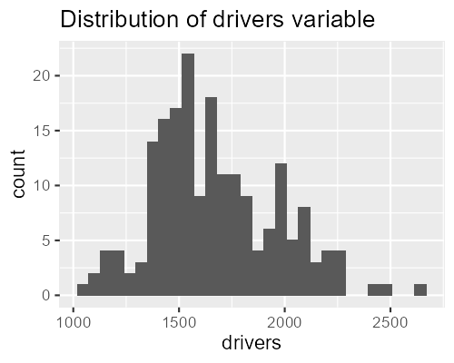

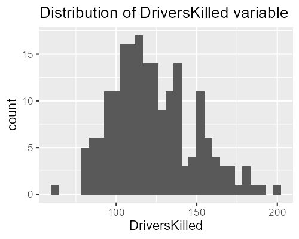

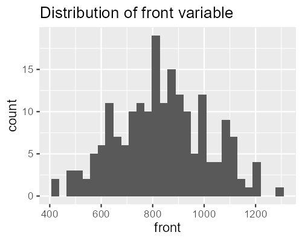

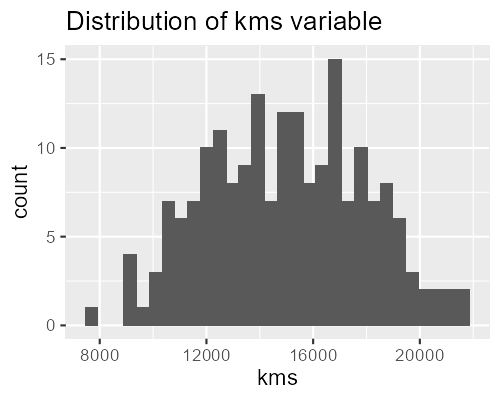

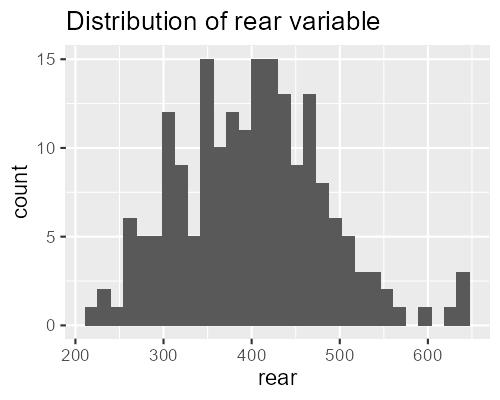

```
corrgrapher(df,
            cor_functions = list(num_num_f = f1,
                                 num_cat_f = f2,
                                 max_cor = 100))
```

## Custom feature importance

When `corrgrapher` function is called on an `explainer` object, it calculates inside importance of features (variables) using `ingredients::feature_importance` function. User may (sometimes should) supply `feature_importance` argument as either:

- An object created using `ingredients::feature_importance` on **the same** `explainer`, or
- A named list of parameters to pass to `ingredients::feature_importance` called inside `corrgrapher` function.

Remember, do **not** change `variables` and `variable_groups` arguments.

[interactive chart not shown]

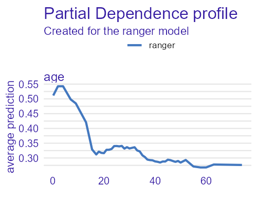

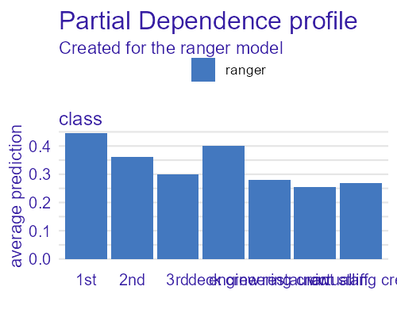

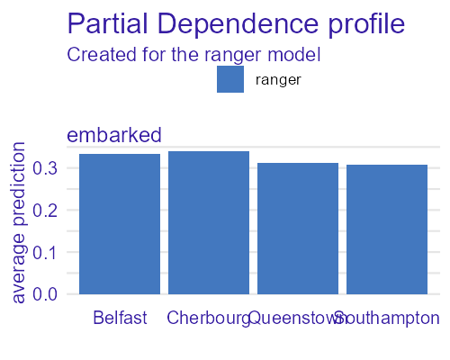

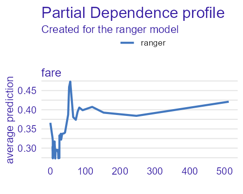

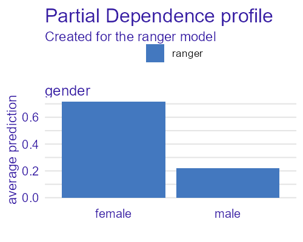

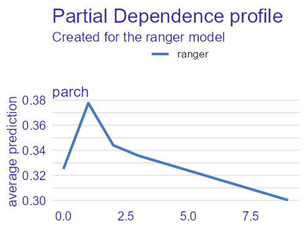

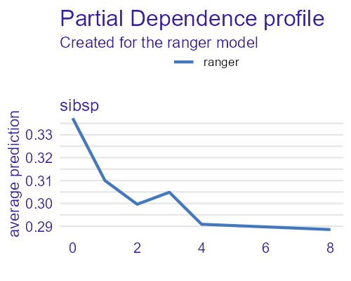

```
library(ranger)
library(DALEX)
#> Welcome to DALEX (version: 2.0).
#> Find examples and detailed introduction at: https://pbiecek.github.io/ema/
#> Additional features will be available after installation of: ggpubr.
#> Use 'install_dependencies()' to get all suggested dependencies
data("titanic_imputed", package='DALEX')
tit_model <- ranger(survived ~ ., data = titanic_imputed, num.trees = 100)
tit_model_exp <- explain(tit_model,
                         data = titanic_imputed[,-8],
                         y = titanic_imputed[, 8],
                         verbose = FALSE)
tit_model_fi <- ingredients::feature_importance(tit_model_exp,
                                                B = 5,
                                                loss_function = loss_accuracy)
tit_cgr_1 <- corrgrapher(tit_model_exp, feature_importance = tit_model_fi)
tit_cgr_2 <- corrgrapher(tit_model_exp,
                         feature_importance = list(B = 20,
                                                   loss_function = loss_one_minus_auc))
tit_cgr_1
```

```
tit_cgr_2
```

[interactive chart not shown]

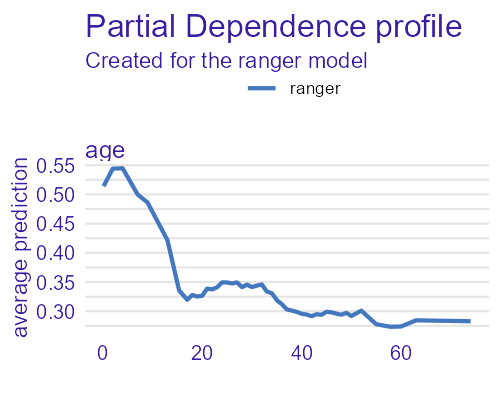

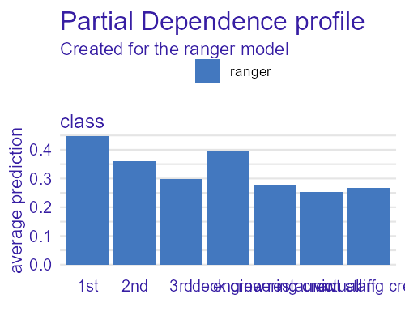

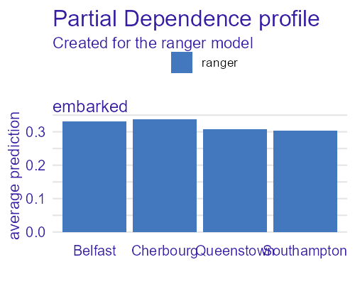

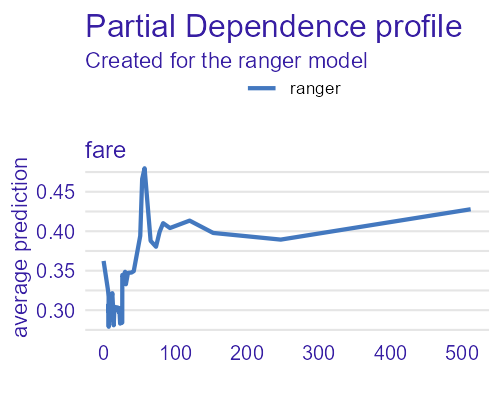

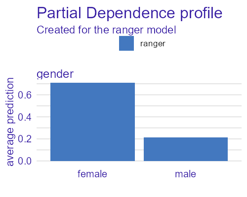

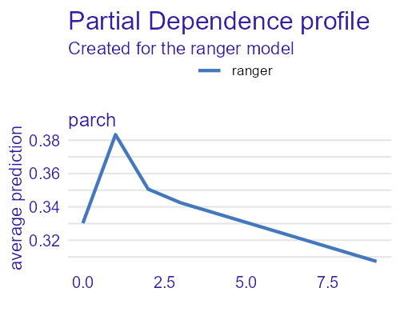

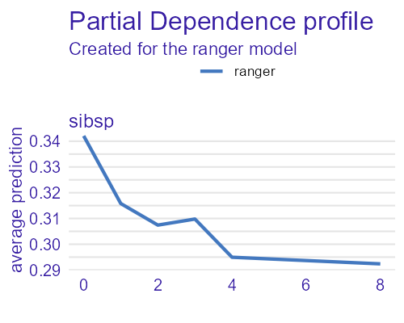

## Custom partial dependence

Similarly to `feature_importance`, user may (sometimes should) supply `partial_dependency` argument. Do **not** change `variable_type`, `variables` or `variable_splits` arguments.

[interactive chart not shown]

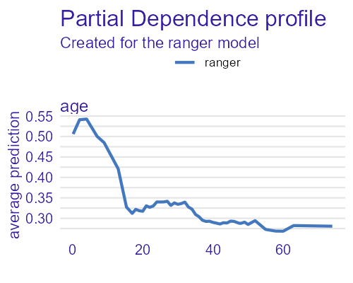

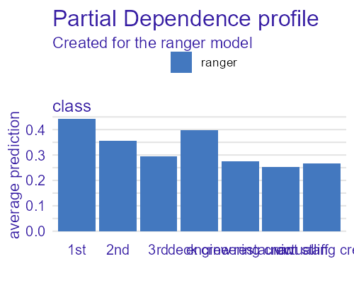

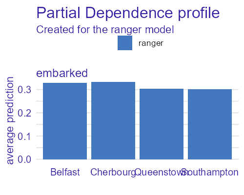

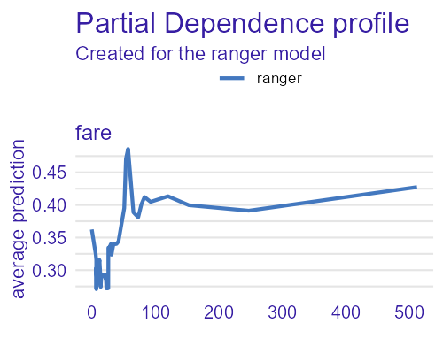

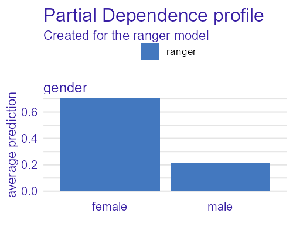

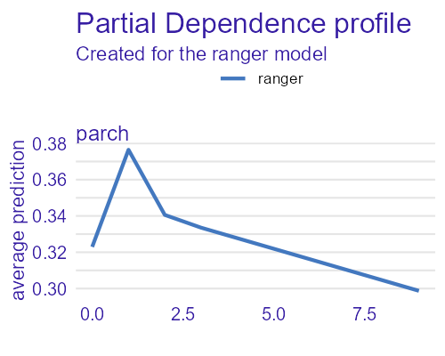

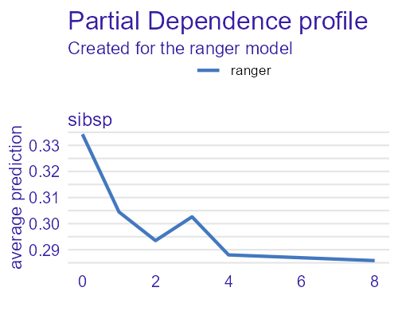

```
tit_model_pds <- ingredients::partial_dependence(tit_model_exp, grid_points = 50, N = 100)

tit_cgr_3 <- corrgrapher(tit_model_exp,
                         feature_importance = tit_model_fi,
                         partial_dependency = tit_model_pds)
tit_cgr_4 <- corrgrapher(tit_model_exp,
                         feature_importance = tit_model_fi,
                         partial_dependency = list(grid_points = 101,
                                                   N = 200))

tit_cgr_3
```

```
tit_cgr_4
```

[interactive chart not shown]

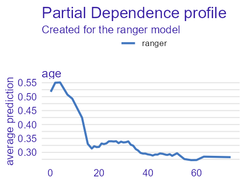

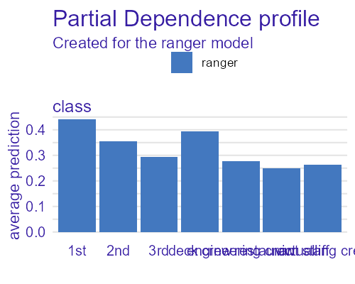

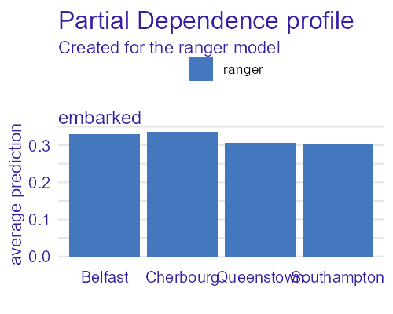

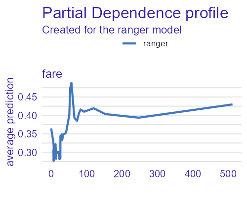

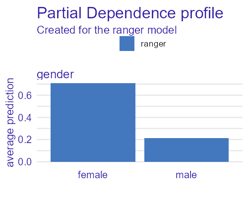

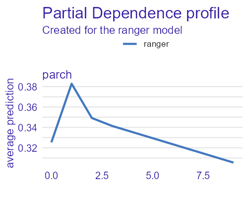

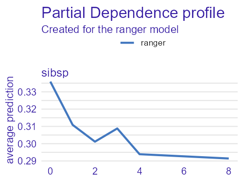

## See also

[Introduction](https://modeloriented.github.io/corrgrapher/articles/Introduction.html) vignette for overall overview of the package.